# Section 3 - Unsupervised Learning

**Student Name: Xinyu Zhang**

**Student ID: 35486244**

## Q3 Self-supervised Neural Network Learning

### Q3-I

### Load Task2C labeled.csv, Task2C unlabeled.csv, and Task2C test.csv datasets, along with the required libraries.

```python
# Importing required libraries
import matplotlib.pyplot as plt
import numpy as np
import sklearn
import sklearn.datasets
import sklearn.linear_model
import matplotlib
import pandas as pd
import numpy as np
import matplotlib.pyplot as plt

import random
import os
from sklearn.metrics import zero_one_loss
from sklearn.linear_model import Perceptron
import torch
import pandas as pd
import seaborn as sns
from sklearn.decomposition import PCA
from sklearn.feature_extraction.text import CountVectorizer, TfidfVectorizer
from sklearn.cluster import KMeans
from sklearn.decomposition import PCA
from sklearn.feature_extraction.text import TfidfTransformer
from helper_functions import *
```

```python
# Set up matplotlib for inline plotting
import matplotlib.pyplot as plt
plt.rcParams['figure.figsize'] = [10.0, 8.0]
%matplotlib inline
```

```python
# load the Task2C_labeled dataset
task2c_labeled_df = pd.read_csv("Dataset_S2_2025/Task2C_labeled.csv")
```

```python
task2c_labeled_df.shape
```

```
(50, 785)
```

```python
# load the Task2C_unlabeled dataset
task2c_unlabeled_df = pd.read_csv("Dataset_S2_2025/Task2C_unlabeled.csv")
```

```python
task2c_unlabeled_df.shape
```

```
(1500, 784)
```

```python
# load the Task2C_test dataset
df_task2c_test = pd.read_csv("Dataset_S2_2025/Task2C_test.csv")
```

```python
labelled_plus_unlabelled_df = pd.concat([task2c_labeled_df.iloc[:,1:], task2c_unlabeled_df])
labelled_plus_unlabelled_df.shape
```

```
(1550, 784)
```

```python
X = np.array(labelled_plus_unlabelled_df.iloc[:,:])
X.shape
```

```
(1550, 784)
```

### Q3-II

### Train an autoencoder with only one hidden layer and change the number of its neurons to 20, 60, 100, ..., 220 (i.e. from 20 to 220 with a step size of 40).

```python
# define the parameters and dataframe
epochs = 250
learning_rate = 0.01

neuron_number = range(20,221,40)
index_id = 0
outcomes_32 = pd.DataFrame(np.empty((len(neuron_number),2)), dtype='float32',columns=['neuron','reconstruction_error'])
```

```python
# define the data preprocessing function
def normalize_dataset(input_data, precomputed_mean=None, precomputed_std=None):
    if precomputed_mean is None or precomputed_std is None:
        precomputed_mean, precomputed_std = input_data.mean(), input_data.std()

    return (input_data - precomputed_mean) / precomputed_std

# calculate Euclidean distance
def compute_reconstruction_Euclidean_distance(original_data, reconstructed_data):
    squared_differences = np.sum(np.square(original_data - reconstructed_data), axis=1)
    return np.mean(np.sqrt(squared_differences))
```

[output not shown]

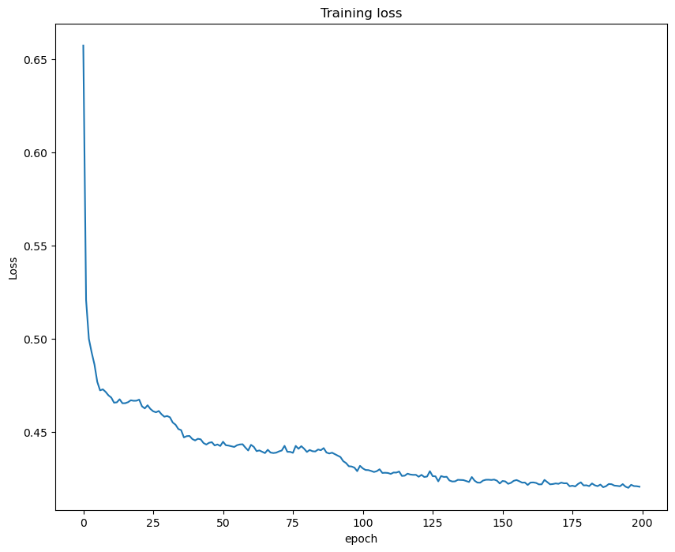

[output not shown]

[output not shown]

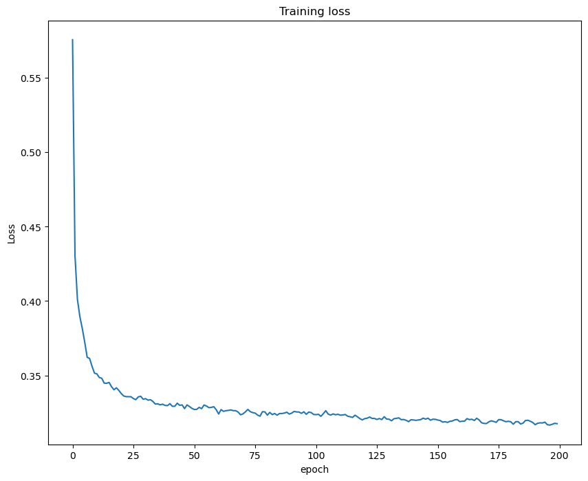

[output not shown]

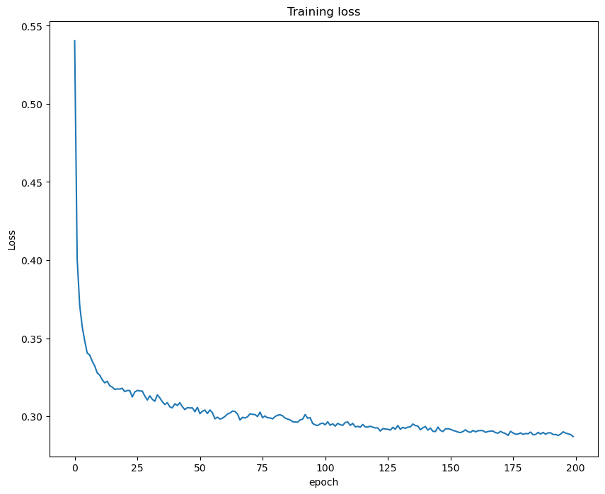

[output not shown]

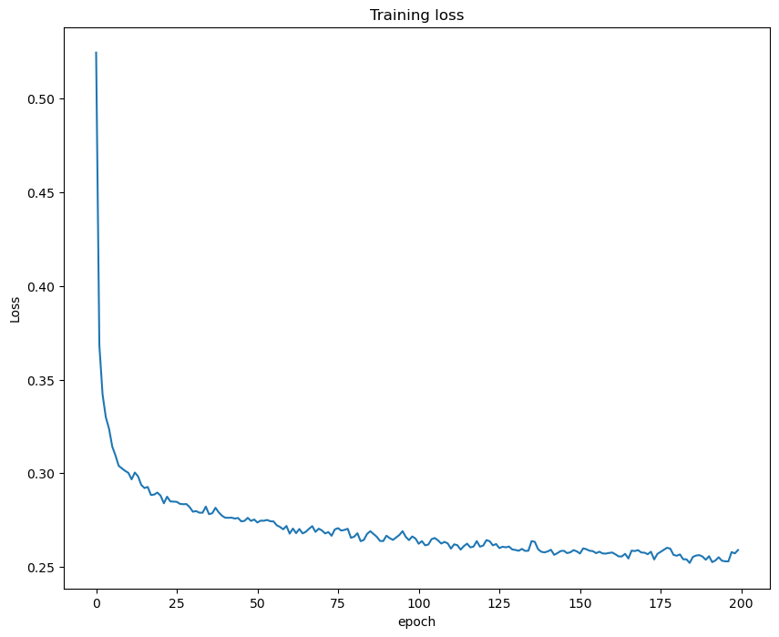

[output not shown]

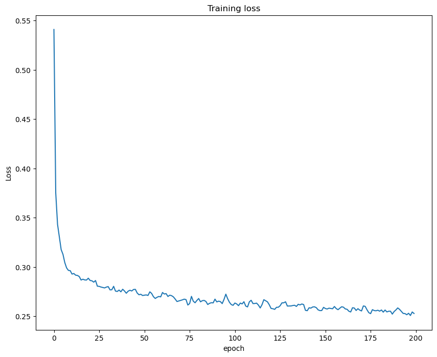

[output not shown]

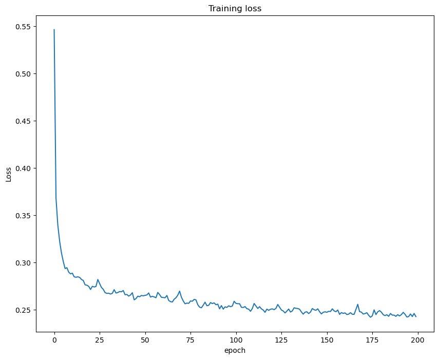

```python
# loop different parameter combinations to create the autoencoder model.
for index, neuron in enumerate(neuron_number):
    AE_model = train_autoencoder(
        X_train = X,
        hidden = [neuron],
        epochs = epochs,
        activation = 'Tanh',
        lr = learning_rate
    )

    # get the output after autoencoder reconstruction
    output = get_deepfeatures(AE_model,X, layer_number=-1)
    # caculate the reconstruction error
    reconstruction_error = compute_reconstruction_Euclidean_distance(normalize_dataset(X),output )
    # record the results
    outcomes_32.iloc[index_id+index,0] = neuron
    outcomes_32.iloc[index_id+index,1] = reconstruction_error
```

### Q3-III

### For each model in Step II, calculate and record the reconstruction error for the autoencoder, which is simply the average of Euclidean distances between the input and output of the autoencoder. Plot these values where the x-axis is the number of units in the middle layer and the y-axis is the reconstruction error. Then, explain your findings based on the plot.

```python
outcomes_32
```

|  | neuron | reconstruction_error |
| --- | --- | --- |
| 0 | 20.0 | 17.908715 |
| 1 | 60.0 | 15.641770 |
| 2 | 100.0 | 14.796687 |
| 3 | 140.0 | 14.137270 |
| 4 | 180.0 | 14.101679 |
| 5 | 220.0 | 13.782276 |

[figure not shown]

```python
# plot the results
plt.plot(neuron_number,outcomes_32["reconstruction_error"],linewidth=1,color='red',label = 'reconstruction_error')
plt.xlabel('Number of neurons in the hidden layer of autoencoder')
plt.ylabel('reconstruction error for the autoencoder')
plt.legend()
```

### explain your findings based on the plot.

As can be seen in the graph, the reconstruction error decreases significantly with increasing the number of neurons. This is because more neurons can capture more complex patterns and structure in the data.

However, increasing the number of neurons to 150 only slightly reduces the reconstruction error, and increasing it further reduces the time efficiency of training.

### Q3-IV

### Build the 3-layer NN to build a classification model using all the original attributes from the training set and change the number of its neurons to 20, 60, 100, ..., 220 (i.e. from 20 to 220 with a step size of 40). For each model, calculate and record the test error.

```python
# Use the classification model to make predictions and extract the output of a specific layer
def model_prediction(test_X, test_y, model, layer_idx):
    test_loader = get_dataloader(test_X, test_y, autoencoder=False, return_dataset=True)[1].tensors[0]
    # Initializing a list to store the output of a specific layer
    outputs = []
    # Hook function,  Automatically called during the forward pass of the model to save the output of a specified layer
    def save_output(mod, inp, out):
        outputs.append(out.data)

    # Register a forward propagation hook at a specified layer,
    # automatically calling the save_output function when the layer's calculations are complete.
    hook_handle = model[layer_idx].register_forward_hook(save_output)

    # Disable gradient calculation
    with torch.no_grad():
        model(test_loader)
    # remove the hook
    hook_handle.remove()
    # Get the first output from the output list (only one hidden layer)
    logits_data = outputs[0].cpu().numpy()
    # Apply the softmax function to the logits to convert the output into a probability distribution
    prob_dist = nn.Softmax(dim=1)(torch.from_numpy(logits_data))
    # get the index of the most probable category for each sample as the predicted label
    pred_labels = prob_dist.argmax(1)

    return pred_labels.numpy()
```

```
Training Model on cuda:0
Epoch 0 out of 250. Loss:2.1012439727783203
Epoch 25 out of 250. Loss:0.03996769851073623
Epoch 50 out of 250. Loss:0.014902756083756685
Epoch 75 out of 250. Loss:0.007805650297086686
Epoch 100 out of 250. Loss:0.004979606892447919
Epoch 125 out of 250. Loss:0.003492296382319182
Epoch 150 out of 250. Loss:0.002641302300617099
Epoch 175 out of 250. Loss:0.002078176476061344
Epoch 200 out of 250. Loss:0.001686057323240675
Epoch 225 out of 250. Loss:0.0013925257953815162
```

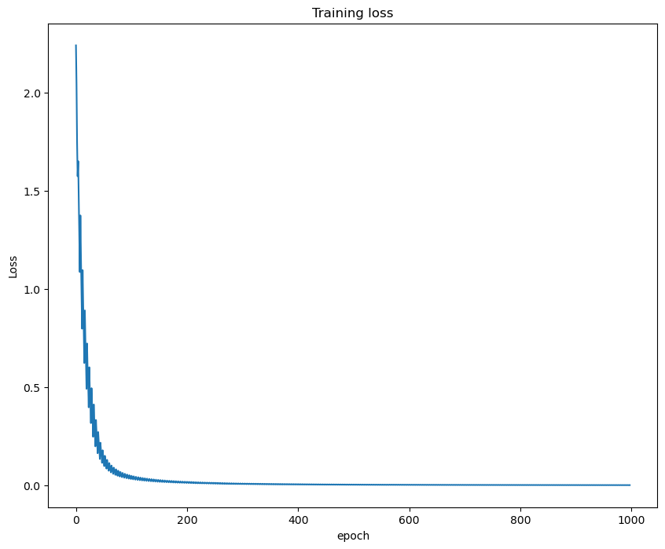

```
Training Model on cuda:0
Epoch 0 out of 250. Loss:2.2099119126796722
Epoch 25 out of 250. Loss:0.010150503134354949
Epoch 50 out of 250. Loss:0.0038263803580775857
Epoch 75 out of 250. Loss:0.0021112865215400234
Epoch 100 out of 250. Loss:0.0013562179228756577
Epoch 125 out of 250. Loss:0.0009527661604806781
Epoch 150 out of 250. Loss:0.0007162913243519142
Epoch 175 out of 250. Loss:0.0005680674985342193
Epoch 200 out of 250. Loss:0.0004613204437191598
Epoch 225 out of 250. Loss:0.00037801882717758417
```

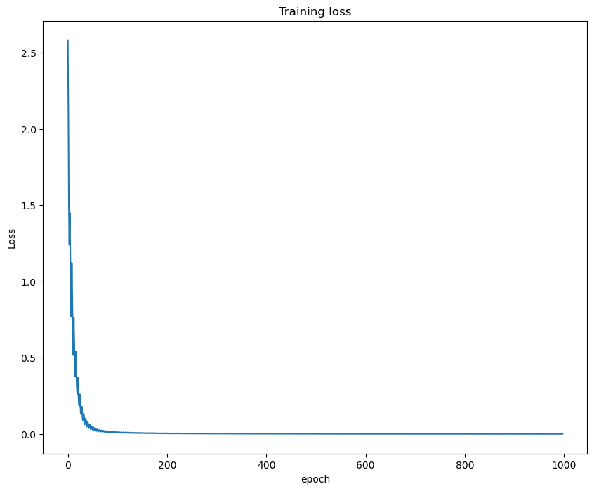

```
Training Model on cuda:0
Epoch 0 out of 250. Loss:2.1008535623550415
Epoch 25 out of 250. Loss:0.005993647442664951
Epoch 50 out of 250. Loss:0.0022700191620970145
Epoch 75 out of 250. Loss:0.0012956730497535318
Epoch 100 out of 250. Loss:0.0008724783838260919
Epoch 125 out of 250. Loss:0.0006313483354460914
Epoch 150 out of 250. Loss:0.00048293908912455663
Epoch 175 out of 250. Loss:0.0003768807691812981
Epoch 200 out of 250. Loss:0.0003053394138987642
Epoch 225 out of 250. Loss:0.00025314480444649234
```

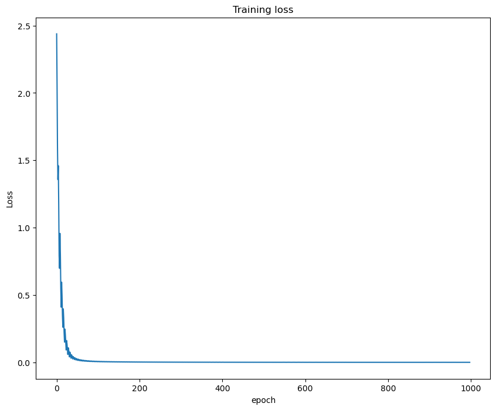

```
Training Model on cuda:0
Epoch 0 out of 250. Loss:2.1485555469989777
Epoch 25 out of 250. Loss:0.0035209081397624686
Epoch 50 out of 250. Loss:0.0014716310615767725
Epoch 75 out of 250. Loss:0.0008306440176966134
Epoch 100 out of 250. Loss:0.0005348219438019441
Epoch 125 out of 250. Loss:0.0003767839116335381
Epoch 150 out of 250. Loss:0.000281198626908008
Epoch 175 out of 250. Loss:0.00022187794638739433
Epoch 200 out of 250. Loss:0.0001800635873223655
Epoch 225 out of 250. Loss:0.00014942354664526647
```

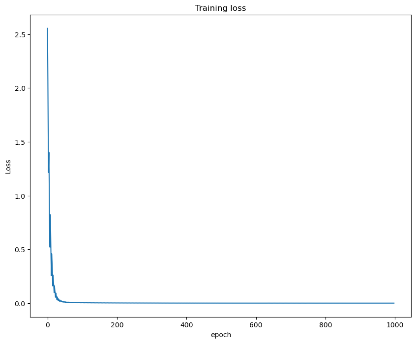

```
Training Model on cuda:0
Epoch 0 out of 250. Loss:2.312168836593628
Epoch 25 out of 250. Loss:0.0023839396599214524
Epoch 50 out of 250. Loss:0.0010852417326532304
Epoch 75 out of 250. Loss:0.0006348122260533273
Epoch 100 out of 250. Loss:0.00041986639917013235
Epoch 125 out of 250. Loss:0.000300899284411571
Epoch 150 out of 250. Loss:0.00023010026052361354
Epoch 175 out of 250. Loss:0.00018341706709179562
Epoch 200 out of 250. Loss:0.00015007232832431328
Epoch 225 out of 250. Loss:0.00012445957418094622
```

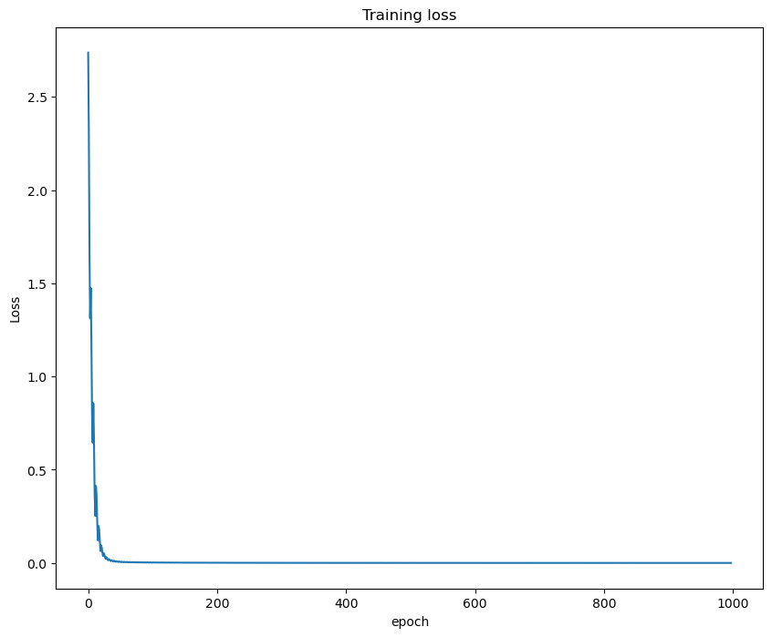

```
Training Model on cuda:0
Epoch 0 out of 250. Loss:2.479583263397217
Epoch 25 out of 250. Loss:0.0018388684693491086
Epoch 50 out of 250. Loss:0.00087132235057652
Epoch 75 out of 250. Loss:0.000523578481079312
Epoch 100 out of 250. Loss:0.00035422747168922797
Epoch 125 out of 250. Loss:0.00025692862982396036
Epoch 150 out of 250. Loss:0.0001940125175678986
Epoch 175 out of 250. Loss:0.00015411415915878024
Epoch 200 out of 250. Loss:0.00012654091005970258
Epoch 225 out of 250. Loss:0.00010595557341730455
```

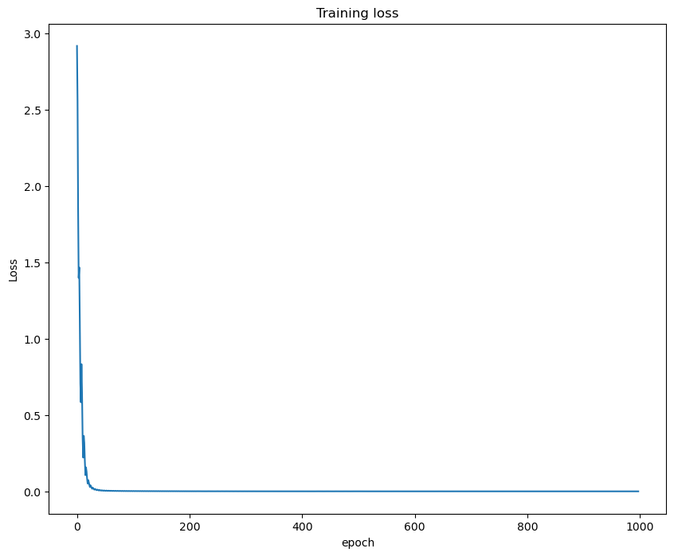

```python
# Get the test dataset
test_X = np.array(df_task2c_test.iloc[:,1:])
test_y = np.array(df_task2c_test.iloc[:,0])
# define the parameters and dataframe
neuron_number = range(20,221,40)
index_id = 0
outcomes_34 = pd.DataFrame(np.empty((6,2)), dtype='float32',columns=['neuron','test_error'])
# loop different parameter combinations to create the classifier_NN model.
for index, neuron in enumerate(neuron_number):
    # create the model
    classifier_NN = train_classifier(
        X_train = np.array(task2c_labeled_df.iloc[:,1:]),
        Y_train = np.array(task2c_labeled_df.iloc[:,0]),
        hidden = [neuron],
        epochs = epochs,
        activation = 'Tanh',
        lr = learning_rate
    )
    # get the prediction
    y_pred = model_prediction(test_X,test_y,classifier_NN, -1)
    # get the test error
    test_error = zero_one_loss(y_test, y_pred)
    # record the results
    outcomes_34.iloc[index_id+index,0] = neuron
    outcomes_34.iloc[index_id+index,1] = test_error
```

```python
outcomes_34
```

|  | neuron | test_error |
| --- | --- | --- |
| 0 | 20.0 | 0.450 |
| 1 | 60.0 | 0.376 |
| 2 | 100.0 | 0.388 |
| 3 | 140.0 | 0.384 |
| 4 | 180.0 | 0.380 |
| 5 | 220.0 | 0.366 |

### Q3-V

### Build augmented self-taught networks using the models learnt in Step II.

```
Training Model on cuda:0
Epoch 0 out of 250. Loss:1.2013430297374725
Epoch 25 out of 250. Loss:0.6401412934064865
Epoch 50 out of 250. Loss:0.5871683806180954
Epoch 75 out of 250. Loss:0.5677767693996429
Epoch 100 out of 250. Loss:0.5577889159321785
Epoch 125 out of 250. Loss:0.5552977547049522
Epoch 150 out of 250. Loss:0.5533658489584923
Epoch 175 out of 250. Loss:0.5545461624860764
Epoch 200 out of 250. Loss:0.5526456534862518
Epoch 225 out of 250. Loss:0.5508195981383324
```

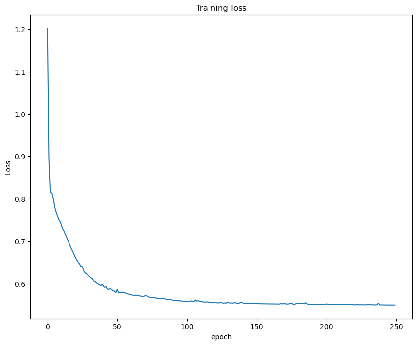

```
Augmented feature dimensionality: (50, 804)
Training Model on cuda:0
Epoch 0 out of 250. Loss:2.252445340156555
Epoch 25 out of 250. Loss:0.38319315388798714
Epoch 50 out of 250. Loss:0.15569565258920193
Epoch 75 out of 250. Loss:0.08372539468109608
Epoch 100 out of 250. Loss:0.05263778753578663
Epoch 125 out of 250. Loss:0.0367827657610178
Epoch 150 out of 250. Loss:0.02748857904225588
Epoch 175 out of 250. Loss:0.021458022529259324
Epoch 200 out of 250. Loss:0.017274116864427924
Epoch 225 out of 250. Loss:0.014187687309458852
```

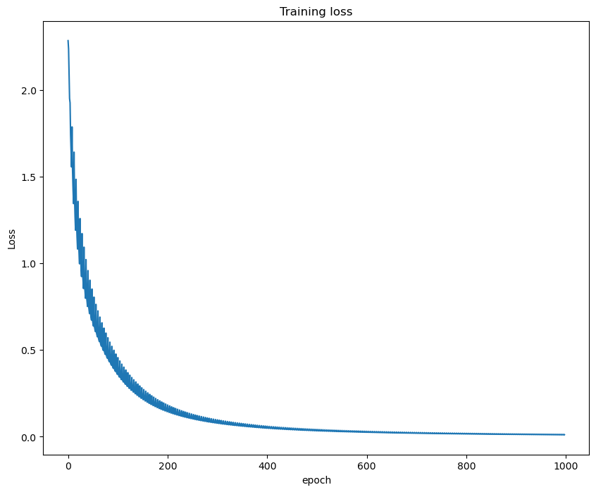

```
Training Model on cuda:0
Epoch 0 out of 250. Loss:1.151442289352417
Epoch 25 out of 250. Loss:0.20271784393116832
Epoch 50 out of 250. Loss:0.13609315117355436
Epoch 75 out of 250. Loss:0.11391357169486582
Epoch 100 out of 250. Loss:0.10760843101888895
Epoch 125 out of 250. Loss:0.0929684674483724
Epoch 150 out of 250. Loss:0.09787320694886148
Epoch 175 out of 250. Loss:0.11212921235710382
Epoch 200 out of 250. Loss:0.10009445709874853
Epoch 225 out of 250. Loss:0.09822757146321237
```

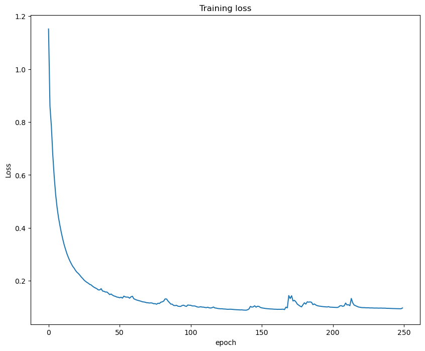

```
Augmented feature dimensionality: (50, 844)
Training Model on cuda:0
Epoch 0 out of 250. Loss:2.1497387290000916
Epoch 25 out of 250. Loss:0.06349883321672678
Epoch 50 out of 250. Loss:0.02085598884150386
Epoch 75 out of 250. Loss:0.011027558706700802
Epoch 100 out of 250. Loss:0.006997503340244293
Epoch 125 out of 250. Loss:0.004894110490567982
Epoch 150 out of 250. Loss:0.0036353044561110437
Epoch 175 out of 250. Loss:0.0028188583673909307
Epoch 200 out of 250. Loss:0.002256422594655305
Epoch 225 out of 250. Loss:0.0018499370489735156
```

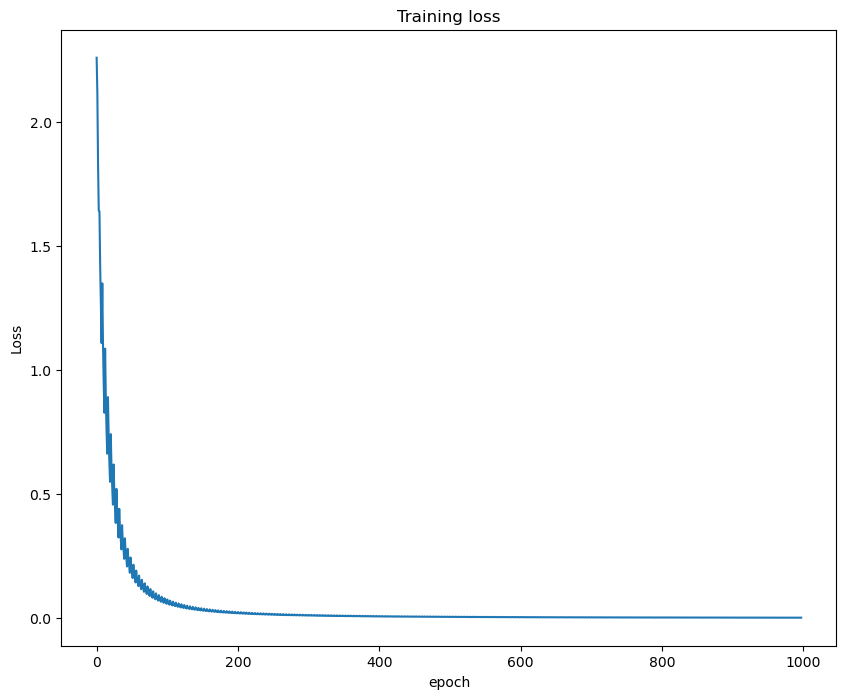

```
Training Model on cuda:0
Epoch 0 out of 250. Loss:1.1265478879213333
Epoch 25 out of 250. Loss:0.15381325036287308
Epoch 50 out of 250. Loss:0.088771783397533
Epoch 75 out of 250. Loss:0.0830944157205522
Epoch 100 out of 250. Loss:0.05134391481988132
Epoch 125 out of 250. Loss:0.04700525209773332
Epoch 150 out of 250. Loss:0.04536562552675605
Epoch 175 out of 250. Loss:0.047748306300491095
Epoch 200 out of 250. Loss:0.033376667997799814
Epoch 225 out of 250. Loss:0.03330293158069253
```

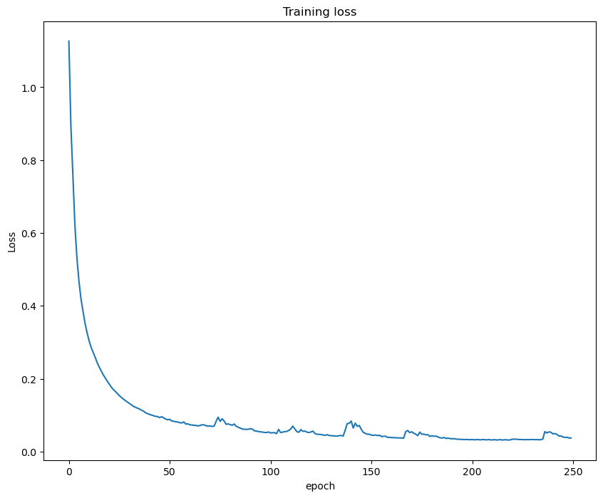

```
Augmented feature dimensionality: (50, 884)
Training Model on cuda:0
Epoch 0 out of 250. Loss:2.0810669660568237
Epoch 25 out of 250. Loss:0.02641611034050584
Epoch 50 out of 250. Loss:0.009392544627189636
Epoch 75 out of 250. Loss:0.005059958843048662
Epoch 100 out of 250. Loss:0.0032294809352606535
Epoch 125 out of 250. Loss:0.0022659117239527404
Epoch 150 out of 250. Loss:0.0016890145052457228
Epoch 175 out of 250. Loss:0.0013129488506820053
Epoch 200 out of 250. Loss:0.0010524420067667961
Epoch 225 out of 250. Loss:0.0008636191560071893
```

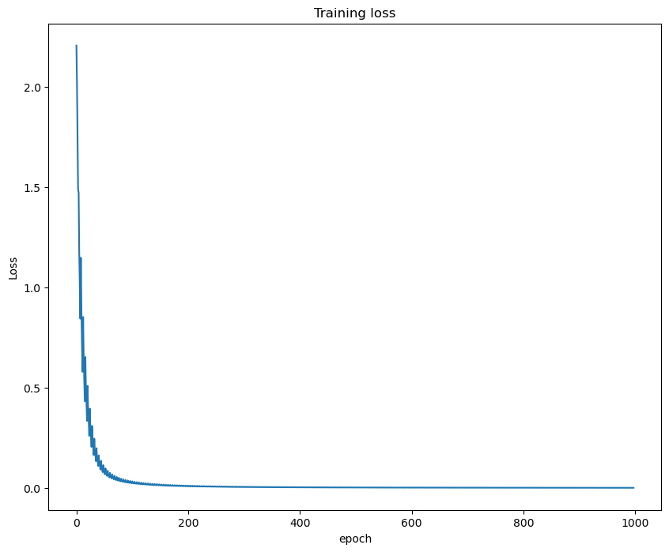

```
Training Model on cuda:0
Epoch 0 out of 250. Loss:1.1566804498434067
Epoch 25 out of 250. Loss:0.1171204581623897
Epoch 50 out of 250. Loss:0.07340179942548275
Epoch 75 out of 250. Loss:0.05985627602785826
Epoch 100 out of 250. Loss:0.05957708600908518
Epoch 125 out of 250. Loss:0.029200258664786816
Epoch 150 out of 250. Loss:0.03592681046575308
Epoch 175 out of 250. Loss:0.024092972744256258
Epoch 200 out of 250. Loss:0.01875370310153812
Epoch 225 out of 250. Loss:0.03213857254013419
```

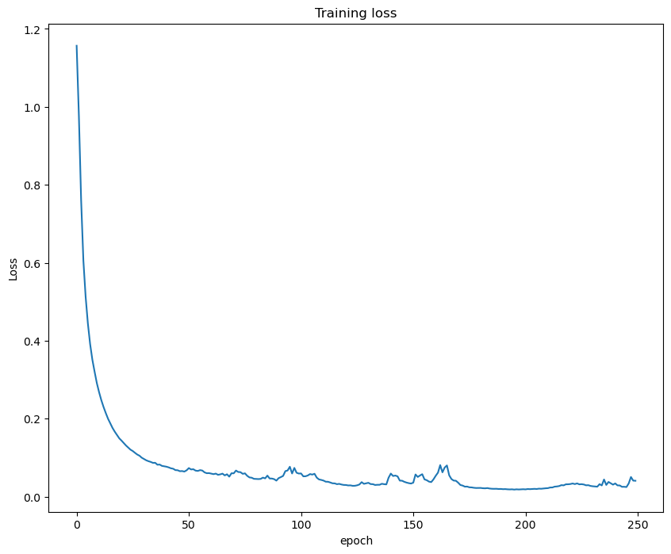

```
Augmented feature dimensionality: (50, 924)
Training Model on cuda:0
Epoch 0 out of 250. Loss:2.051815152168274
Epoch 25 out of 250. Loss:0.016707565519027412
Epoch 50 out of 250. Loss:0.006113019277108833
Epoch 75 out of 250. Loss:0.0033137368445750326
Epoch 100 out of 250. Loss:0.002119298223988153
Epoch 125 out of 250. Loss:0.0014874600092298351
Epoch 150 out of 250. Loss:0.0011080057520302944
Epoch 175 out of 250. Loss:0.0008602991656516679
Epoch 200 out of 250. Loss:0.0006889374417369254
Epoch 225 out of 250. Loss:0.000564913461857941
```

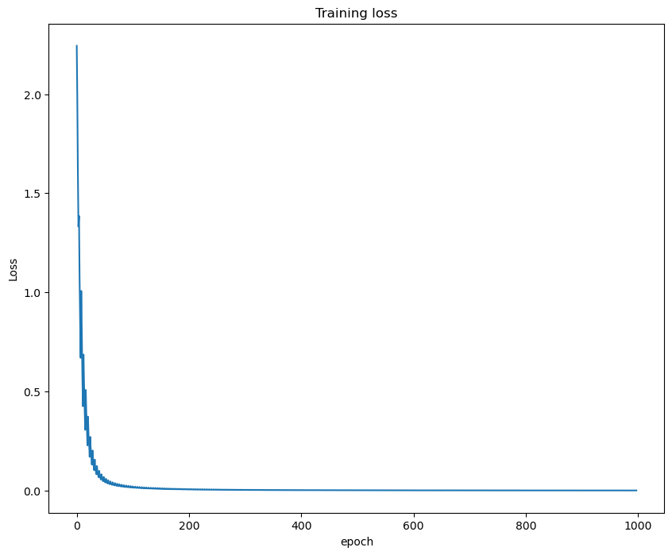

```
Training Model on cuda:0
Epoch 0 out of 250. Loss:1.2749035358428955
Epoch 25 out of 250. Loss:0.09284145513083786
Epoch 50 out of 250. Loss:0.04619639692828059
Epoch 75 out of 250. Loss:0.046224309131503105
Epoch 100 out of 250. Loss:0.03307369817048311
Epoch 125 out of 250. Loss:0.08037456311285496
Epoch 150 out of 250. Loss:0.019381060265004635
Epoch 175 out of 250. Loss:0.040824692230671644
Epoch 200 out of 250. Loss:0.017436925321817398
Epoch 225 out of 250. Loss:0.046079461462795734
```

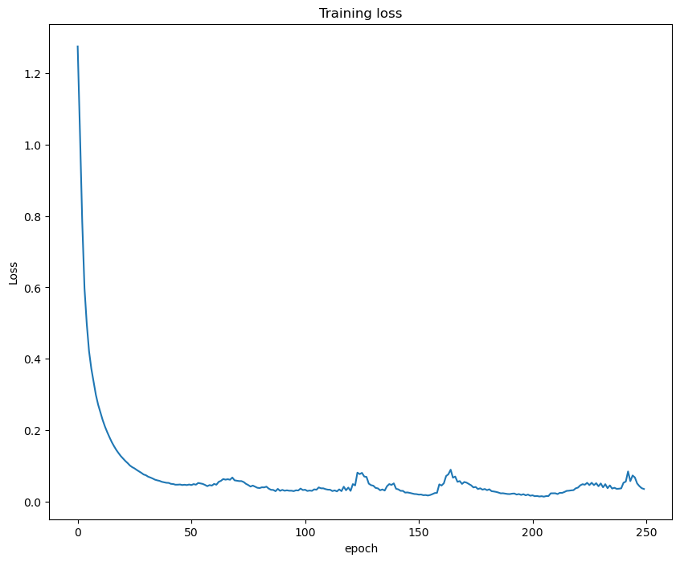

```
Augmented feature dimensionality: (50, 964)
Training Model on cuda:0
Epoch 0 out of 250. Loss:2.057530701160431
Epoch 25 out of 250. Loss:0.012000127229839563
Epoch 50 out of 250. Loss:0.0045132426312193274
Epoch 75 out of 250. Loss:0.0024530534719815478
Epoch 100 out of 250. Loss:0.0015692287270212546
Epoch 125 out of 250. Loss:0.0011009594090864994
Epoch 150 out of 250. Loss:0.0008198856376111507
Epoch 175 out of 250. Loss:0.000636553482763702
Epoch 200 out of 250. Loss:0.0005096038803458214
Epoch 225 out of 250. Loss:0.0004176968923275126
```

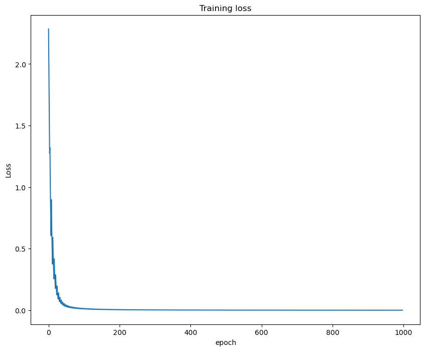

```
Training Model on cuda:0
Epoch 0 out of 250. Loss:1.3240624070167542
Epoch 25 out of 250. Loss:0.08929172868374735
Epoch 50 out of 250. Loss:0.05417787563055754
Epoch 75 out of 250. Loss:0.05704038217663765
Epoch 100 out of 250. Loss:0.03181282803416252
Epoch 125 out of 250. Loss:0.05422125104814768
Epoch 150 out of 250. Loss:0.033396505285054445
Epoch 175 out of 250. Loss:0.060330964624881744
Epoch 200 out of 250. Loss:0.05797549430280924
Epoch 225 out of 250. Loss:0.041536256205290556
```

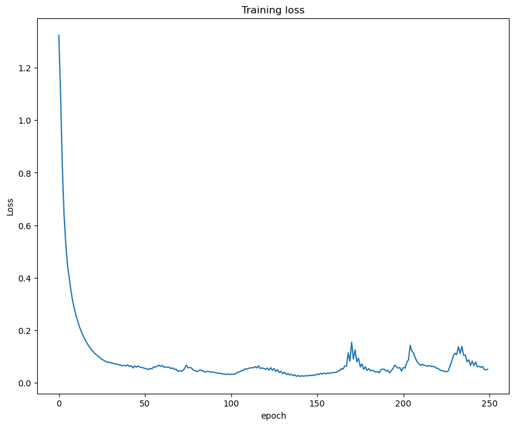

```
Augmented feature dimensionality: (50, 1004)
Training Model on cuda:0
Epoch 0 out of 250. Loss:2.0414215326309204
Epoch 25 out of 250. Loss:0.008957820595242083
Epoch 50 out of 250. Loss:0.0035338845918886364
Epoch 75 out of 250. Loss:0.00195415856433101
Epoch 100 out of 250. Loss:0.0012588621757458895
Epoch 125 out of 250. Loss:0.0008853967410686892
Epoch 150 out of 250. Loss:0.0006600327396881767
Epoch 175 out of 250. Loss:0.0005127998738316819
Epoch 200 out of 250. Loss:0.00041070803672482725
Epoch 225 out of 250. Loss:0.0003367573062860174
```

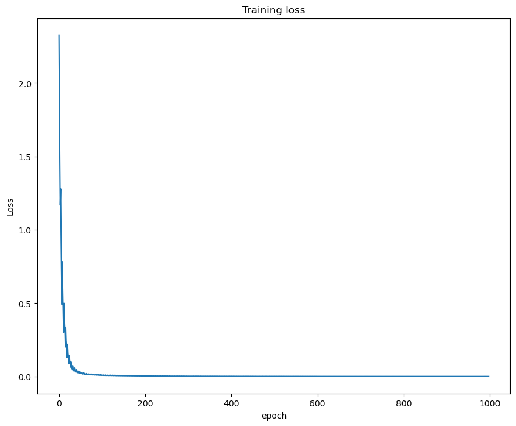

```python
## Initialize hyperparameters and results container
hidden_unit_counts = range(20, 221, 40)
current_index = 0
performance_metrics = pd.DataFrame(np.empty((6, 2)), dtype='float32', columns=['hidden_units', 'classification_error'])

## Iterate through various architectural configurations to build classifier networks
for iteration_count, hidden_units in enumerate(hidden_unit_counts):
    # Initialize and train autoencoder model
    encoder_model = train_autoencoder(
        X_train = task2c_labeled_df.iloc[:, 1:],S
        hidden = [hidden_units],
        epochs = epochs,
        activation = 'Tanh',
        lr = learning_rate
    )

    ## Extract latent representations from autoencoder's bottleneck layer
    encoded_features = get_deepfeatures(encoder_model, task2c_labeled_df.iloc[:, 1:], layer_number=1)  # Middle layer

    # # Validate feature dimensions match hidden units count
    # if encoded_features.shape[1] != hidden_units:
    #     print(f"Warning: Feature dimension mismatch. Expected {hidden_units}, got {encoded_features.shape[1]}")

    ## Combine original features with encoded features
    augmented_feature_set = np.concatenate([task2c_labeled_df.iloc[:, 1:], encoded_features], axis=1)
    print(f"Augmented feature dimensionality: {augmented_feature_set.shape}")

    ## Construct and train classifier neural network
    classification_network = train_classifier(
        X_train = np.array(augmented_feature_set),
        Y_train = np.array(task2c_labeled_df.iloc[:, 0]),
        hidden = [hidden_units],
        epochs = epochs,
        activation = 'Tanh',
        lr = 0.001
    )

    ## Generate encoded representations for test dataset
    test_encoded_features = get_deepfeatures(encoder_model, X_test, layer_number=1)

    ## Create augmented test feature set
    augmented_test_features = np.concatenate([X_test, test_encoded_features], axis=1)

    ## Perform prediction on test data
    predicted_labels = model_prediction(augmented_test_features, y_test, classification_network, -1)

    ## Calculate classification error
    classification_error = zero_one_loss(y_test, predicted_labels)

    ## Record performance metrics
    performance_metrics.iloc[current_index + iteration_count, 0] = hidden_units
    performance_metrics.iloc[current_index + iteration_count, 1] = classification_error
```

```python
outcomes_35
```

[output not shown]

### Q3-VI

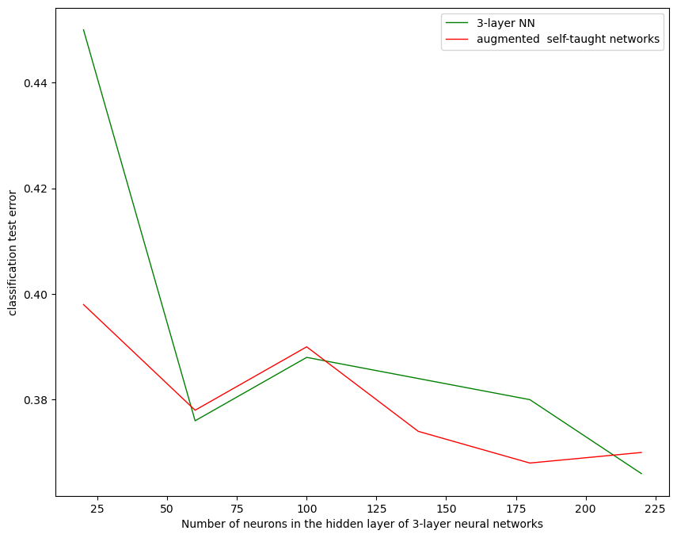

```python
plt.plot(neuron_number,outcomes_34["test_error"],linewidth=1,color='green',label = '3-layer NN')
plt.plot(neuron_number,outcomes_35["test_error"],linewidth=1,color='red',label = 'augmented  self-taught networks')
plt.xlabel('Number of neurons in the hidden layer of 3-layer neural networks')
plt.ylabel('classification test error')
plt.legend()
```